# Implementation of Evolution Model for Subspecies

Adapted Framework

2024-12-07

# Introduction

This document implements the model of evolution for subspecies, based on a birth-death process with preferential attachment and mutation dynamics. The model incorporates the survival of the fittest principle while integrating environmental and stochastic factors to simulate evolutionary population dynamics.

# Parameters

Set the key parameters for the simulation.

```r
# Load libraries
library(ggplot2)
library(dplyr)
library(tidyr)

# Define parameters
set.seed(123)
p <- 0.6  # Probability of birth
r <- 0.4  # Probability of mutation
n_steps <- 100  # Number of time steps
initial_population <- data.frame(fitness = c(0.3, 0.6, 0.9), size = c(10, 20, 5))
```

# Simulation Framework

The simulation follows a discrete-time process with the following rules:

1. **Birth**: With probability `p`, an individual is born.
   - With probability `r`, the individual is a mutant with a random fitness value.
   - Otherwise, preferential attachment determines its fitness.
2. **Death**: With probability `1 - p`, the least fit individual dies.

## Simulation Function

Define a function to simulate the population dynamics over time.

```r
simulate_population <- function(initial_population, n_steps, p, r) {
  population <- initial_population
  results <- list()

  for (t in 1:n_steps) {
    if (runif(1) < p) {
      # Birth event
      if (runif(1) < r) {
        # Mutation: New fitness level uniformly in [0, 1]
        new_fitness <- runif(1)
        population <- population %>%
          add_row(fitness = new_fitness, size = 1)
      } else {
        # Preferential attachment
        total_size <- sum(population$size)
        probabilities <- population$size / total_size
        chosen <- sample(seq_len(nrow(population)), size = 1, prob = probabilities)
        population$size[chosen] <- population$size[chosen] + 1
      }
    } else {
      # Death event: Remove one individual from the least fit group
      least_fit <- which.min(population$fitness)
      if (population$size[least_fit] > 1) {
        population$size[least_fit] <- population$size[least_fit] - 1
      } else {
        population <- population[-least_fit, ]
      }
    }

    # Store the population state
    results[[t]] <- population
  }

  results
}
```

# Running the Simulation

Simulate the evolution of the population using the defined parameters and function.

```r
# Run simulation
simulation_results <- simulate_population(initial_population, n_steps, p, r)

# Prepare results for visualization
plot_data <- bind_rows(lapply(seq_along(simulation_results), function(t) {
  data <- simulation_results[[t]]
  data$time <- t
  data
}))
```

# Visualization

## Fitness Distribution Over Time

Visualize how the fitness distribution evolves across the simulation timeline.

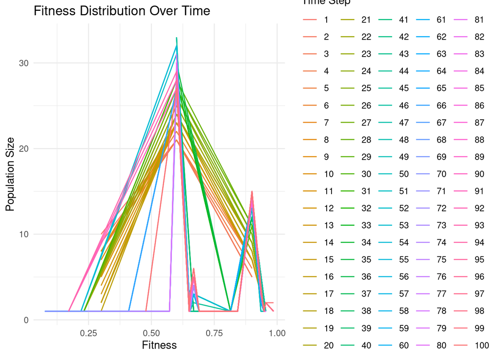

```r
ggplot(plot_data, aes(x = fitness, y = size, color = as.factor(time))) +
  geom_line() +
  labs(title = "Fitness Distribution Over Time",
       x = "Fitness",
       y = "Population Size",
       color = "Time Step") +
  theme_minimal()
```

## Population Dynamics

### Total Population

Plot the total population size over time.

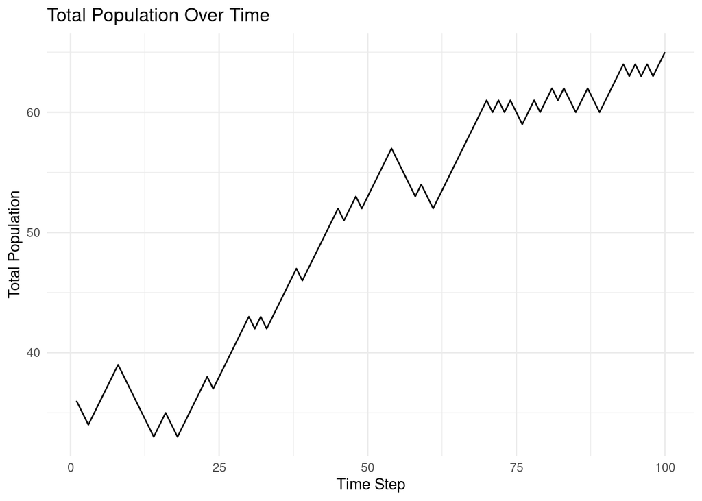

```r
summary_data <- plot_data %>%
  group_by(time) %>%
  summarise(total_population = sum(size),
            mean_fitness = weighted.mean(fitness, size))

ggplot(summary_data, aes(x = time, y = total_population)) +
  geom_line() +
  labs(title = "Total Population Over Time",
       x = "Time Step",
       y = "Total Population") +
  theme_minimal()
```

### Mean Fitness

Plot the mean fitness of the population over time.

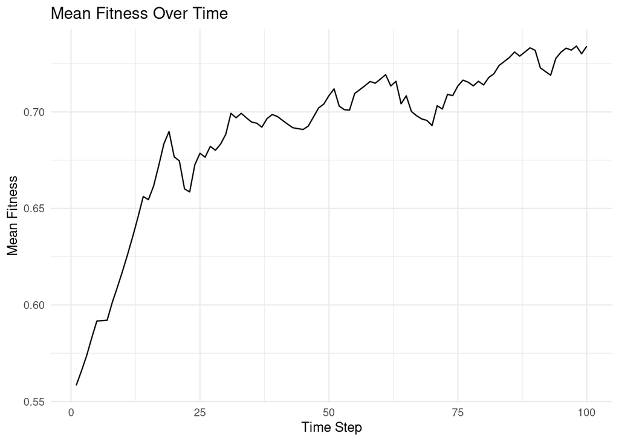

```r
ggplot(summary_data, aes(x = time, y = mean_fitness)) +
  geom_line() +
  labs(title = "Mean Fitness Over Time",
       x = "Time Step",
       y = "Mean Fitness") +
  theme_minimal()
```

# Conclusion

This implementation provides a framework for simulating and visualizing the evolution of subspecies populations. The integration of mutation and preferential attachment mechanisms highlights key evolutionary dynamics that can be adapted for specific ecological studies.